# ECS 132 - Homework 5

Sam Tsoi, sgtsoi@ucdavis.edu, 913032178

11/5/2018

# Problem 1 / Properties of Markov Chain Transition Matrices

## 1.1

0.3 + 0.3 + a = 1  
a = .4

0.1 + b + 0.4 = 1 b = .5

c + 0.8 + 0.1 = 1 c = .1

## 1.2

0.1 + a + 0.5 = 1

a = 0.4

b + 0.6 + 0.2 = 1

b = 0.2

0.7 + c + 0.1 = 1  
c = 0.2

# Problem 2 / Branch Prediction

## 2.1

*Write out the transition matrix for this chain and find the missing probabilities.*
$$\begin{equation}
P =
\begin{bmatrix}
1-\alpha & \alpha \\
\beta & 1-\beta \\
\end{bmatrix}
=
\begin{bmatrix}
0.1 & 0.9 \\
0.1 & 0.9 \\
\end{bmatrix}
\end{equation}$$

## 2.2

*What are the steady-state probabilities for this chain?*
$$\begin{equation}
\begin{bmatrix}
\lambda_1 \lambda_2
\end{bmatrix}
\begin{bmatrix}
0.1 & 0.9 \\
0.1 & 0.9 \\
\end{bmatrix}= \begin{bmatrix}
\lambda_1 \lambda_2
\end{bmatrix}
\end{equation}$$
A =
$$\begin{bmatrix}
0.1 & 1 \\
0.1 & 1 \\
\end{bmatrix}$$

```r
a=matrix(c(0.1-1, 0.1, 1,1), 2,2, byrow = F)
inva = solve(a)
#lambda = [0 0 1] * inv(A)
lambdas = inva[2,]
lambdas
```

```
## [1] 0.1 0.9
```

Therefore, $\lambda_1$ = 0.1 and $\lambda_2$ = 0.9

## 2.3

```r
0.1 + (0.9 * 0.1) + (0.9 * 0.9 * 0.1) + (0.9 * 0.9 * 0.9 * 0.1)
```

```
## [1] 0.3439
```

## 2.4

*4. Explain the above considering that the most common control statements that branch areconditional statements and loops.*

Above shows that until it reaches success again, repeat. So, for 2.3, we will do a for or while loop. While it is still a failure, multiply the current probability by the probability of failure, which is 0.9. Until it is not a failure thus a success, then the probability of that is 0.1.

# Problem 3 / Flip-flop Convergence

A 2-state Markov Chain hasα=β=.99.

## 3.1

*Findλ1andP128usingR.*
$$\begin{equation}
P =
\begin{bmatrix}
1-\alpha & \alpha \\
\beta & 1-\beta \\
\end{bmatrix}
=
\begin{bmatrix}
.01 & 0.99 \\
0.99 & 0.01 \\
\end{bmatrix}
\end{equation}$$

```r
p <- matrix(c(.01,.99,.99,.01),2,2,byrow=F)
eigen(p)$values[1]
```

```
## [1] 1
```

Therefore, $\lambda_1 = 1$

```r
p^128
```

```
##               [,1]          [,2]
## [1,] 1.000000e-256  2.762517e-01
## [2,]  2.762517e-01 1.000000e-256
```

## 3.2

*Simulate this Markov Chain for 200 steps.*

```r
simulation <- function( mat, steps) {
        n <- nrow(mat)
        new <- numeric(steps)
        new[1] <- 1

        for (i in 2:steps) {
            temp = mat[new[i-1],]
            new[i] <- sample(1:n, 1, prob = temp)
        }
        return(new)
 }


sim200 = simulation(p,200)
sim200
```

```
##   [1] 1 2 1 2 1 2 1 2 1 2 1 2 1 2 1 2 1 2 1 2 1 2 1 2 1 2 1 2 1 2 1 2 1 2 1
##  [36] 1 2 1 2 1 2 1 2 1 2 1 2 1 2 1 2 1 2 1 2 1 2 1 2 1 1 2 1 2 1 2 1 2 1 2
##  [71] 1 2 1 2 1 2 1 2 1 2 1 2 1 2 1 2 1 2 1 2 1 2 1 2 1 2 1 2 1 2 1 2 1 2 1
## [106] 2 1 2 1 2 1 2 1 2 1 2 1 2 1 2 1 2 1 2 1 2 1 2 1 2 1 2 1 2 1 2 1 2 1 2
## [141] 1 2 1 2 1 2 1 2 1 2 1 2 1 2 1 2 1 2 1 2 1 2 1 2 1 2 1 2 1 2 1 2 1 2 1
## [176] 2 1 2 1 2 1 2 1 2 1 2 1 2 1 2 1 2 1 2 1 2 1 2 1 2
```

## 3.3.

*Plot the running average of the “time spent” in state 1.*

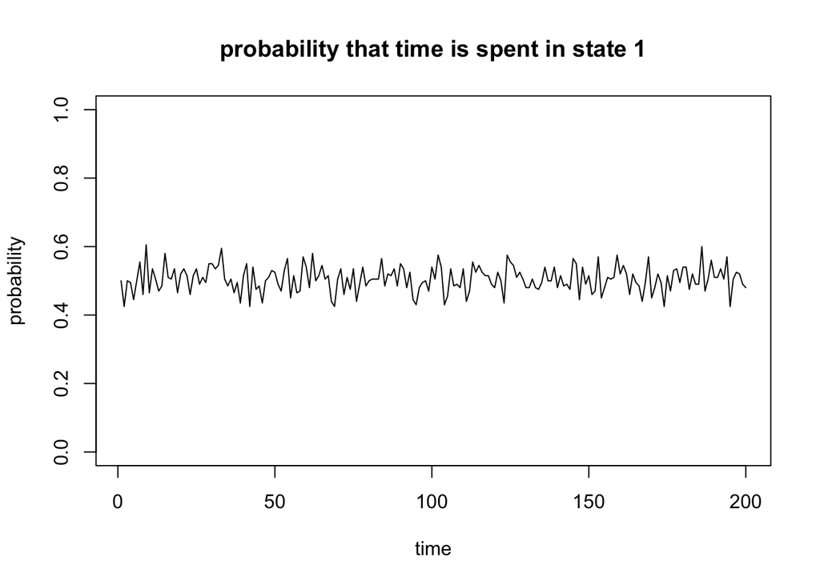

```r
  plot((rbinom(200,200,sum(sim200 == 1)/200))/200, type = 'l', ylab= 'probability', ylim = c(0,1), xlab= 'time', main = 'probability that time is spent in state 1')
```

## 3.4.  
*The autocorrelation function shows how much the dependency on the starting state “wearsoff” over time. Plot the autocorrelation over all of the steps (not just the first 30 steps).*

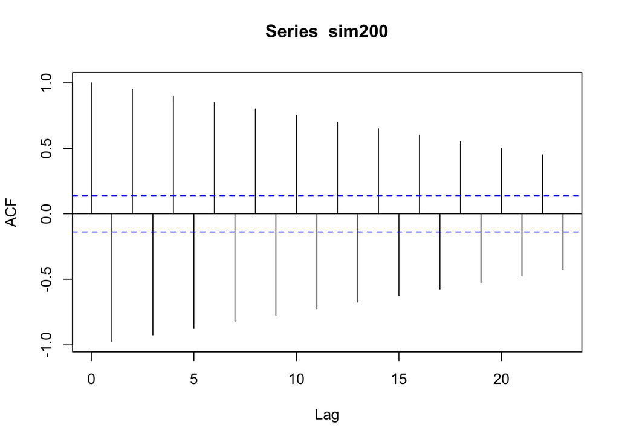

# Problem 4 / Innovation Diffusion

*In the bookDiffusion of Innovationsby Everett M. Rogers, The Innovation-Decision process isbroken up into the following discrete steps:* 1. Knowledge: The individual knows about your innovation.2. Persuasion: The individual is persuaded to adopt your innovation.3. Decision: The individual decides to adopt your innovation (usually by purchasing, but frictioncan be reduced by relying on advertising revenue).4. Implementation: The individual begins implementing your innovation.5. Confirmation: Typically this stage involves customization of the innovation, and use of it incommon practice. ## 4.1 *Create a transition matrix for this chain.*

```r
transition <- matrix(c(.1,.9,0,0,0,
              0.05, 0.3, 0.65, 0, 0,
              0, 0.08, 0.1, 0.82, 0,
              0, 0, 0.01, 0.2, 0.79,
              0,0,0,.09,.91),5,5,byrow=T)
transition
```

```
##      [,1] [,2] [,3] [,4] [,5]
## [1,] 0.10 0.90 0.00 0.00 0.00
## [2,] 0.05 0.30 0.65 0.00 0.00
## [3,] 0.00 0.08 0.10 0.82 0.00
## [4,] 0.00 0.00 0.01 0.20 0.79
## [5,] 0.00 0.00 0.00 0.09 0.91
```

## 4.2

*Find the missing probabilities.*  
1->2: 1-0.1 = 0.9  
2->3: 1-0.3-0.05 = 0.65  
3->4: 1-0.1-0.08 = 0.82  
4->5: 1-0.2-0.01 = 0.79

## 4.3

*Find the steady-state probabilities that an individual will end up in any particular state.*
$$\begin{equation}
\begin{bmatrix}
v & w &x & y & z \\
\end{bmatrix}
\begin{bmatrix}
0.1 & 0.9 & 0 & 0 & 0 \\
0.05 & 0.3 & 0.65 & 0 & 0 \\
0 & 0.08 & 0.1 & 0.82 & 0 \\
0 & 0 & 0.01 & 0.2 & 0.79 \\
0 & 0 & 0 & 0.09 & 0.91 \\
\end{bmatrix}= \begin{bmatrix}
v & w &x & y & z \\
\end{bmatrix}
\end{equation}$$

0.1v+0.05w+0x+0y+0z = v  
0.9v+0.3w+0.08x+0y+0z = w  
0v+0.65w+0.1x+0.01y+0z = x  
0v+0w+0.82x+0.2y+0.09z = y  
v+w+x+y+z=1

```r
A <- matrix(c(
              .1-1,.9,0,0,1,
              0.05, 0.3-1, 0.65, 0, 1,
              0, 0.08, 0.1-1, 0.82, 1,
              0, 0, 0.01, 0.2-1, 1,
              0,0,0,0.09,1),5,5,byrow=T)
A
```

```
##       [,1]  [,2]  [,3]  [,4] [,5]
## [1,] -0.90  0.90  0.00  0.00    1
## [2,]  0.05 -0.70  0.65  0.00    1
## [3,]  0.00  0.08 -0.90  0.82    1
## [4,]  0.00  0.00  0.01 -0.80    1
## [5,]  0.00  0.00  0.00  0.09    1
```

```r
solveA <- solve(A) # get the inverse of p
V = solveA[5,] #get the last row
V
```

```
## [1] 8.516056e-06 1.532890e-04 1.245473e-03 1.021288e-01 8.964639e-01
```

Therefore, $\lambda_1$ = 8.51605610^{-6}, $\lambda_2$ = 1.532890110^{-4}, $\lambda_3$ = 0.0012455, $\lambda_4$ = 0.1021288, and $\lambda_5$ = 0.8964639.

To check my work, I will do V*A = [0 0 0 0 1]

```r
#check
V %*% A
```

```
##               [,1]         [,2] [,3]         [,4] [,5]
## [1,] -1.694066e-21 1.355253e-20    0 1.387779e-17    1
```

It does!  
## 4.4 *Where would you put in more effort in diffusing this innovation?*  
Since the steady state for state 1, state 2, and state 3 are essentially 0, in the long run, the probability of the innovation staying in these 3 states are very very slim. The probability that it will be in state 5 is around 90%, according to our steady state probabilities. Therefore, since ideally we want to go to state 5, the steady state with the highest porbability that is not in state 5 in state 4, with around 10% in the long run. We want to put more effort in the implementation stage to make sure this innovation runs successfully more times.

# Problem 5 / Gambler’s Ruin

*Kim has $4 and Chris has $3. At each step of the game, both players toss fair coins. If both coinsshow heads, Chris pays Kim $1, if both coins show tails, Kim pays Chris $1. Otherwise no moneychanges hands and they both keep playing. The game only stops when one of the players runs outof money.* ## 5.1 *Model this as a Markov Chain in which the state is the amount of money Kim has.* Suppose S = {HH,HT,TH,TT}. However, given that one got H on the first try and if that person got T, they stay in the same state. Similarly, given that one got T on the first try and that person got H on the second, they stay in the same state. Therefore, we can consider S={HH,TT} which is the only time a transition will be absorbed.

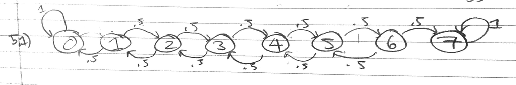

## 5.2

*What is the probability that Kim wins?*  
Since this is a fair case,

n/T = n/(n+m) = 4/7

```
## [1] 0.5714286
```

# Problem 6 / Flipping Out

*You are flipping a fair coin repeatedly. LetXnrepresent the outcome of the2 previous coin flipsat stepn(i.e. if you have flipped heads twice in a row, then the state would be HH).*

## 6.1

*Write out the transition matrix for this chain.*

```r
p <- matrix(c(1,0,0,0,
              .5,0.5,0,0,
              0,0,0.5,0.5,
              0,0,0,1), dimnames = list(c("HH", "HT", "TH", "TT"),c("HH", "HT", "TH", "TT")),4,4, byrow= T)
p
```

```
##     HH  HT  TH  TT
## HH 1.0 0.0 0.0 0.0
## HT 0.5 0.5 0.0 0.0
## TH 0.0 0.0 0.5 0.5
## TT 0.0 0.0 0.0 1.0
```

## 6.2

*UseRto findP16.*

```r
p^16
```

```
##              HH           HT           TH           TT
## HH 1.000000e+00 0.000000e+00 0.000000e+00 0.000000e+00
## HT 1.525879e-05 1.525879e-05 0.000000e+00 0.000000e+00
## TH 0.000000e+00 0.000000e+00 1.525879e-05 1.525879e-05
## TT 0.000000e+00 0.000000e+00 0.000000e+00 1.000000e+00
```